# Deliverable II

Oeuyown Kim

February 16, 2022

This analysis uses data from the Race and Social Equity (RSE) Index from the City of Seattle and Covid-19 case data from King County to explore the latent concept of being disadvantaged. The disadvantage measure will be used to analyze how tracts with higher disadvantage scores were impacted by Covid-19.

# Cluster Analysis

## Prepare Data

```r
# load libraries
library(tidyverse)
library(dplyr)
```

**Read in data from the Race and Social Equity Index from the City of Seattle:**

```r
link='https://raw.githubusercontent.com/oeuyown/computational-thinking/main/deliverable_1/data/Racial_and_Social_Equity_Composite_Index.csv'

# read in data
rseIndex = read.csv(link)

# reset indexes to R format:
row.names(rseIndex)=NULL

# omit NA values
rseIndex = na.omit(rseIndex)

# sort columns by GEOID
rseIndex = arrange(rseIndex, GEOID10)
```

### I. Data to Cluster

**a. Subset the data**

```r
selection=c("GEOID10","COMPOSITE_PERCENTILE", "RACE_ELL_ORIGINS_PERCENTILE","SOCIOECONOMIC_PERCENTILE","HEALTH_PERCENTILE")

dataToCluster=rseIndex[,selection]
```

**b. Set labels as row index**

```r
dataToCluster$GEOID10=NULL
row.names(dataToCluster)=dataToCluster$GEOID10
```

**c. Decide if data needs to be transformed**

The data does not need to be transformed because they all fall within a similar range (they are on the same scale) and there are no outliers.

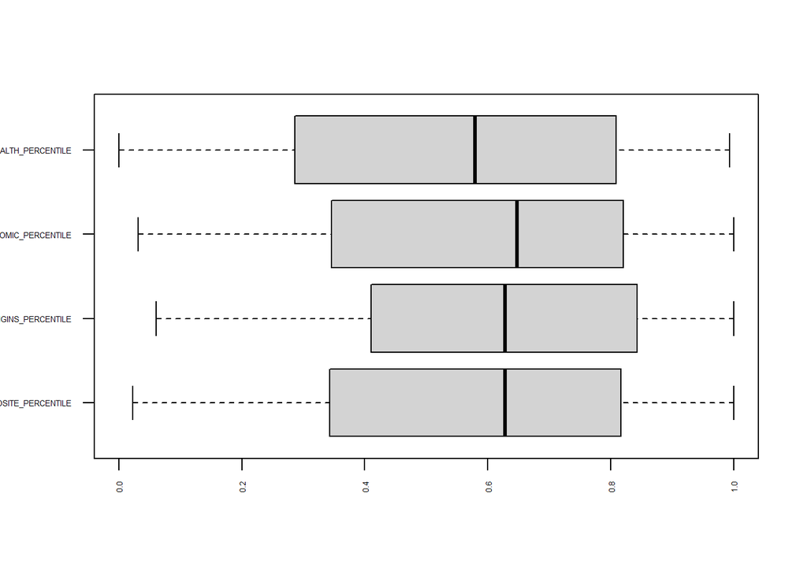

```r
boxplot(dataToCluster,horizontal = T, las=2,cex.axis=0.4)
```

### II. Compute the DISTANCE MATRIX:

**d. Set random seed**

```r
set.seed(999)
```

**e. Decide distance method and compute distance matrix**

```r
library(cluster)
dataToCluster_DM=daisy(x=dataToCluster, metric = "gower")
```

## Compute Clusters

### 1. Apply function

**a. Estimate optimal number of clusters** The optimal number of clusters is 4.

```r
library(factoextra)
```

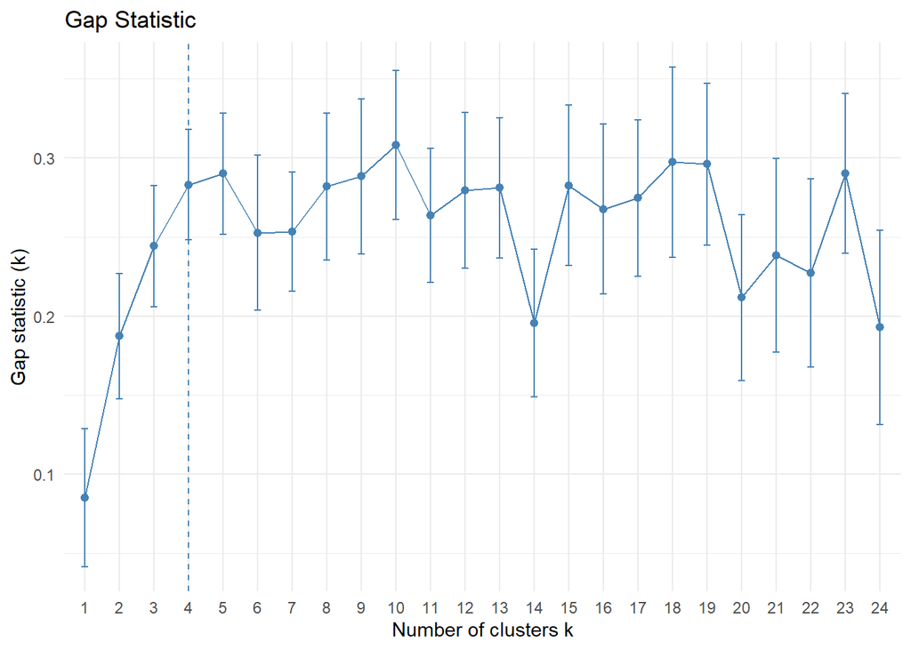

```r
gap_stat = clusGap(dataToCluster, FUN = kmeans, K.max = 24, B = 50)

fviz_gap_stat(gap_stat) + theme_minimal() + ggtitle("Gap Statistic")
```

```r
NumberOfClusterDesired=4

# Partitioning technique
res.pam = pam(x=dataToCluster_DM,
              k = NumberOfClusterDesired,
              cluster.only = F)

# Hierarchical technique- agglomerative approach
library(factoextra)
res.agnes= hcut(dataToCluster_DM,
                k = NumberOfClusterDesired,
                isdiss=TRUE,
                hc_func='agnes',
                hc_method = "ward.D2")

# Hierarchical technique- divisive approach
res.diana= hcut(dataToCluster_DM,
                k = NumberOfClusterDesired,
                isdiss=TRUE,
                hc_func='diana',
                hc_method = "ward.D2")
```

### 2. Clustering results.

**2.1 Add results to original data frame**

```r
rseIndex$pam=as.factor(res.pam$clustering)
rseIndex$agn=as.factor(res.agnes$cluster)
rseIndex$dia=as.factor(res.diana$cluster)
```

**2.2 Verify ordinality in clusters**

Pam Check

```
##   pam COMPOSITE_PERCENTILE
## 1   1            0.9087500
## 2   2            0.6861429
## 3   3            0.4104211
## 4   4            0.1395000
```

Agnes Check

```
##   agn COMPOSITE_PERCENTILE
## 1   1            0.9030952
## 2   2            0.6863158
## 3   3            0.4188500
## 4   4            0.1395000
```

Diana Check

```
##   dia COMPOSITE_PERCENTILE
## 1   1            0.8965909
## 2   2            0.6767895
## 3   3            0.4173333
## 4   4            0.1507692
```

### 3. Evaluate Results.

**3.1 Plot silhouettes**

Pam Silhouette

```
##   cluster size ave.sil.width
## 1       1   20          0.59
## 2       2   21          0.30
## 3       3   19          0.25
## 4       4   12          0.63
```

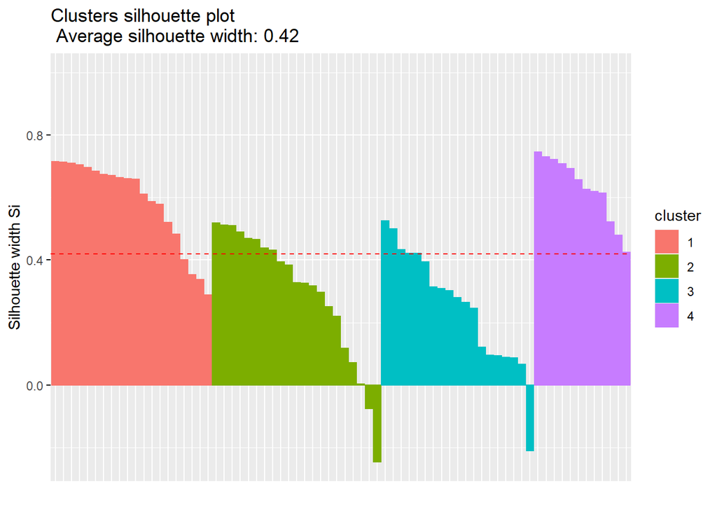

Agnes Silhouette

```
##   cluster size ave.sil.width
## 1       1   21          0.56
## 2       2   19          0.34
## 3       3   20          0.23
## 4       4   12          0.64
```

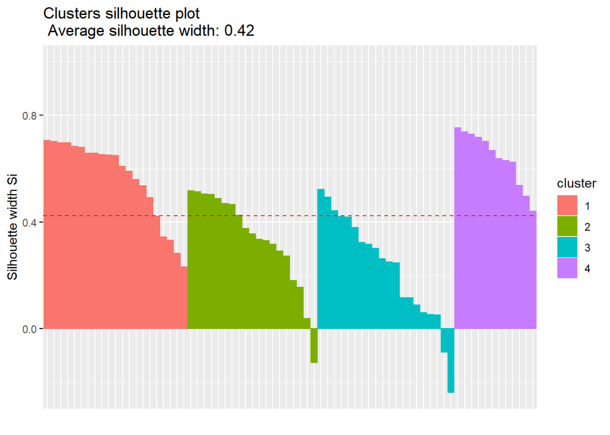

Diana Silhouette: This is the best clustering method for this set of data because it’s the only one without negative values and it does not return any observations that are badly clustered, unlike the Pam and Agnes methods.

```
##   cluster size ave.sil.width
## 1       1   22          0.54
## 2       2   19          0.35
## 3       3   18          0.25
## 4       4   13          0.60
```

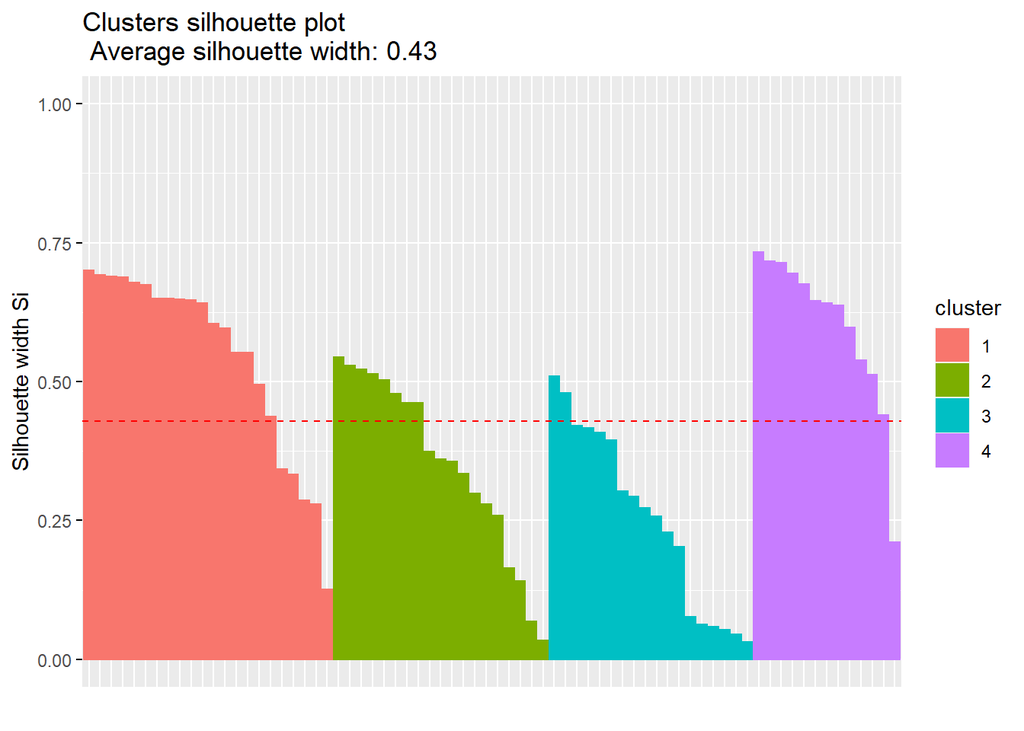

**3.2 Detecting cases badly clustered**

```r
pamEval=data.frame(res.pam$silinfo$widths)
agnEval=data.frame(res.agnes$silinfo$widths)
diaEval=data.frame(res.diana$silinfo$widths)

pamPoor=rownames(pamEval[pamEval$sil_width<0,])
agnPoor=rownames(agnEval[agnEval$sil_width<0,])
diaPoor=rownames(diaEval[diaEval$sil_width<0,])

diaPoor
```

```
## character(0)
```

## Compare Clustering

**Prepare a bidimensional map using distances**

```r
projectedData = cmdscale(dataToCluster_DM, k=2)

# save coordinates to original data frame:
rseIndex$dim1 = projectedData[,1]
rseIndex$dim2 = projectedData[,2]
```

**See the “map”**

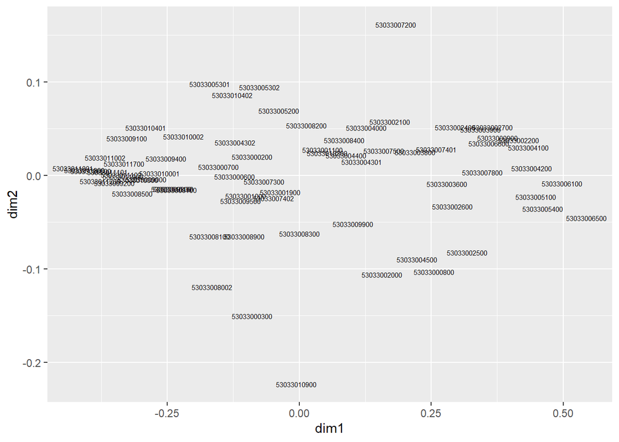

```r
base= ggplot(data=rseIndex,
             aes(x=dim1, y=dim2,
                 label=GEOID10))
base + geom_text(size=2)
```

**Plot results from PAM**

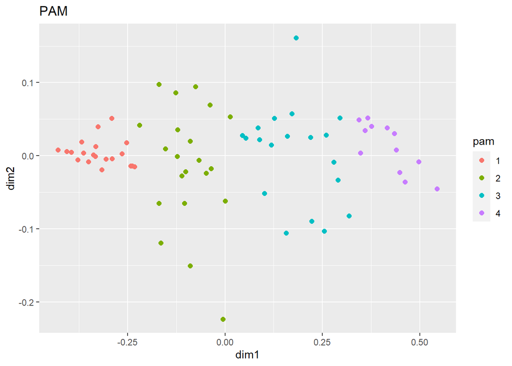

**Plot results from Hierarchical AGNES**

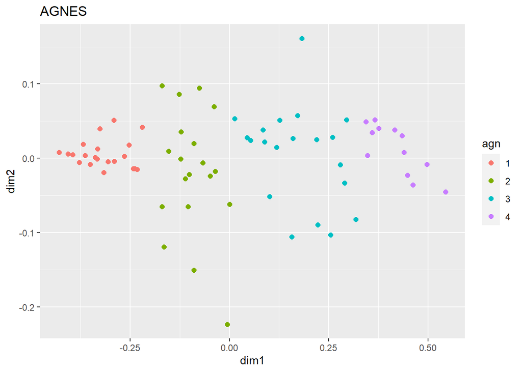

**Plot results from Hierarchical DIANA**

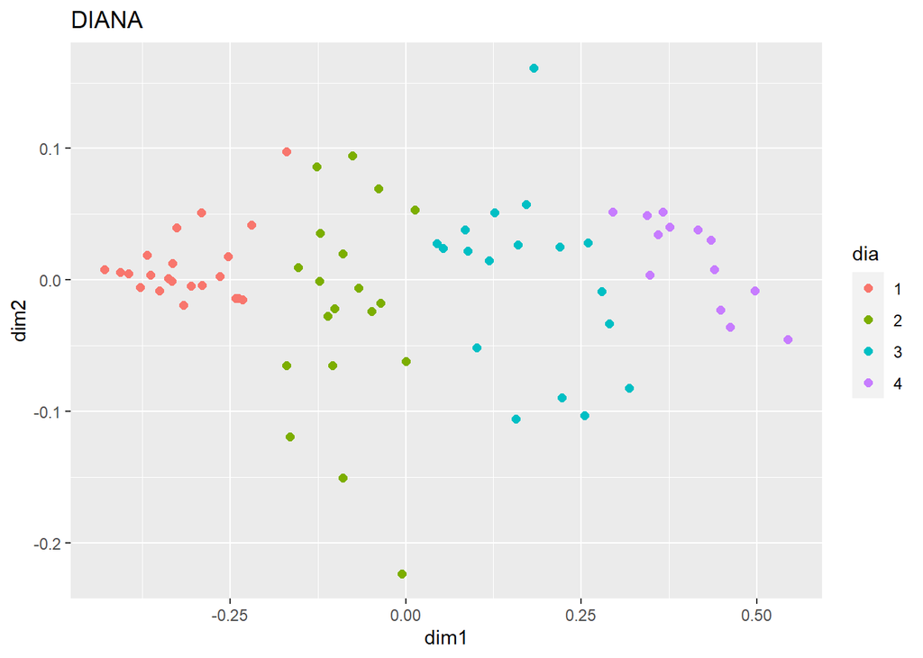

**Compare visually**

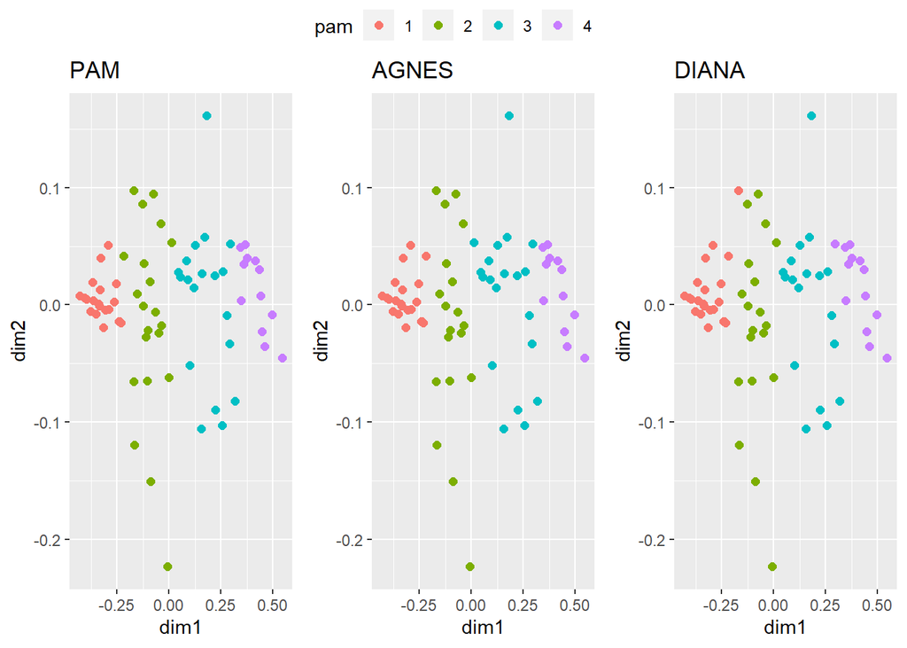

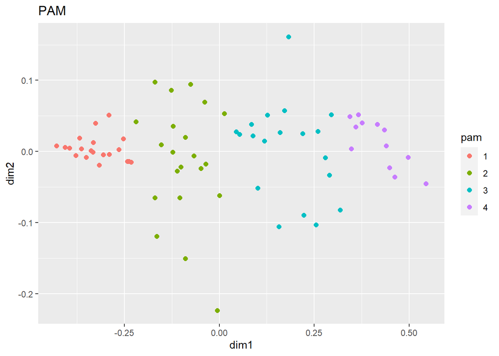

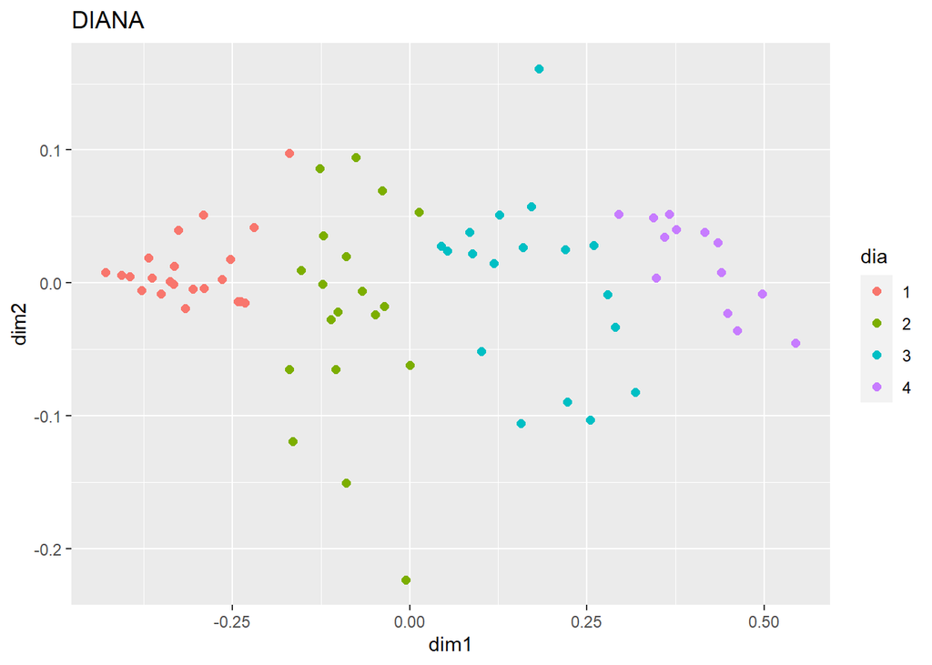

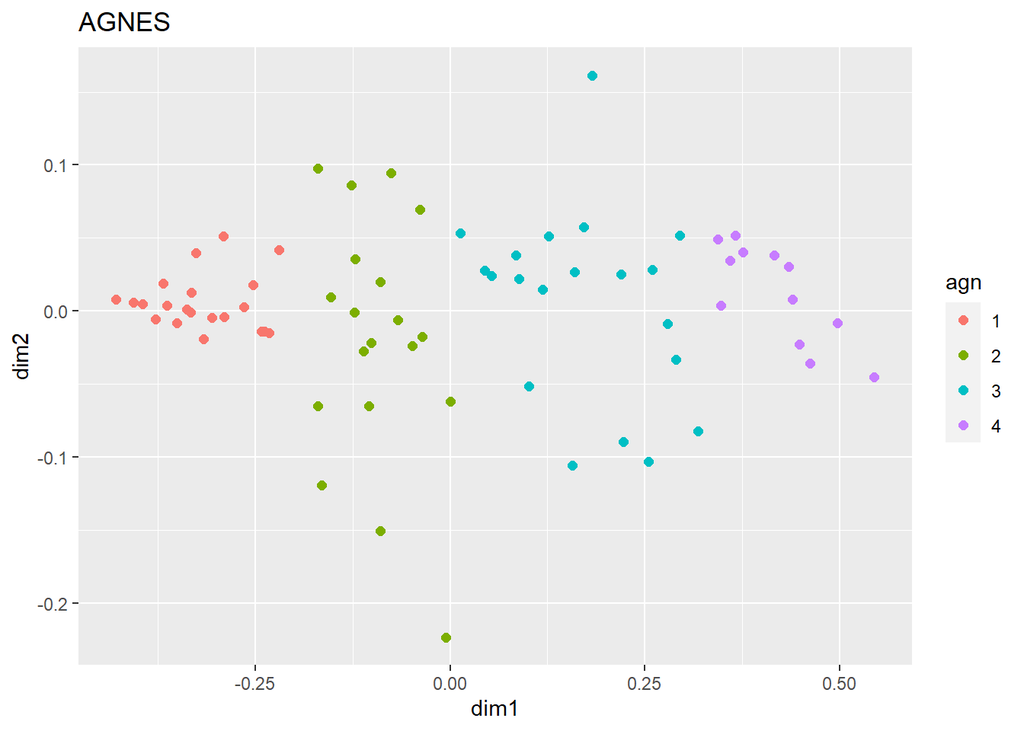

**The Dendogram (for hierarchical approaches)**

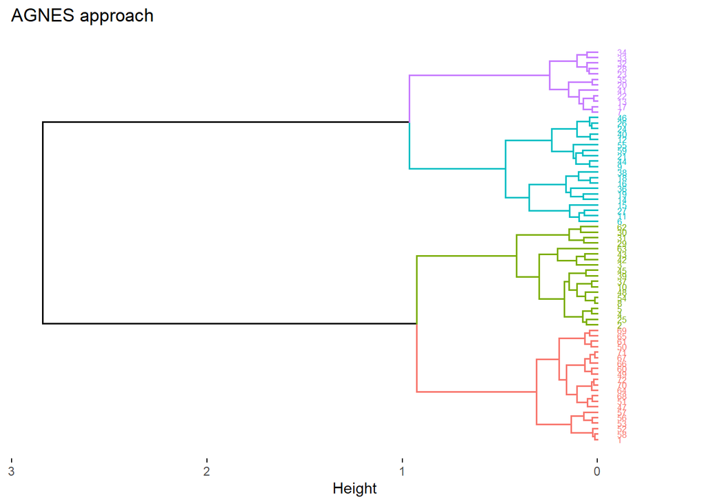

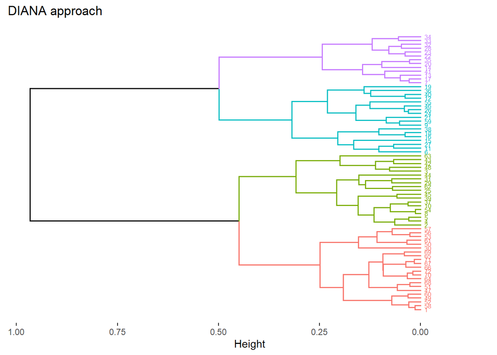

## Factor Analysis

### Subset the Origina Data Frame

```r
selection=c("GEOID10","COMPOSITE_PERCENTILE", "RACE_ELL_ORIGINS_PERCENTILE","SOCIOECONOMIC_PERCENTILE","HEALTH_PERCENTILE")

dataForFA=rseIndex[,selection]
```

### Confirmatory Factor Analysis

```r
names(dataForFA)
```

```
## [1] "GEOID10"                     "COMPOSITE_PERCENTILE"
## [3] "RACE_ELL_ORIGINS_PERCENTILE" "SOCIOECONOMIC_PERCENTILE"
## [5] "HEALTH_PERCENTILE"
```

```r
library(lavaan)
model='equity=~RACE_ELL_ORIGINS_PERCENTILE + SOCIOECONOMIC_PERCENTILE + HEALTH_PERCENTILE'

fit<-cfa(model, data = dataForFA,std.lv=TRUE)
indexCFA=lavPredict(fit)
indexCFA[1:10]
```

```
##  [1]  0.71045501  0.17007099  0.67957044  0.54346486  0.56678304 -0.80056408
##  [7] -1.75152065  0.19371861 -0.40045229 -0.01444228
```

**Force the data to return to “0 to 10”**

```r
library(scales)
indexCFANorm=rescale(as.vector(indexCFA),
                     to = c(0, 10))
indexCFANorm[1:10]
```

```
##  [1] 7.8428117 6.2323625 7.7507697 7.3451486 7.4146413 3.3396816 0.5056464
##  [8] 6.3028370 4.5320924 5.6824771
```

```r
rseIndex$demo_FA=indexCFANorm
rseIndex$demo_FA
```

```
##  [1]  7.8428117  6.2323625  7.7507697  7.3451486  7.4146413  3.3396816
##  [7]  0.5056464  6.3028370  4.5320924  5.6824771  4.8289360  4.2077535
## [13]  0.2117682  1.8468976  4.1955489  3.1278379  0.9874410  3.3628528
## [19]  1.7974845  2.2736884  2.8802181  0.2982488  1.0317345  5.3884429
## [25]  6.9540006  5.3690259  4.6279059  0.7066482  6.5958243  9.1934742
## [31]  8.4416015  1.4331603  0.4890349  0.6700885  2.5288232  2.7643896
## [37]  5.6671174  3.7714076  7.2185033  4.7729726  0.0000000  8.1848272
## [43]  7.2230253  4.9172619  6.6819373  5.8577903  9.4917113  7.0169443
## [49]  8.1415007  9.8311692  9.3938665  7.4294477  8.0072693  6.4589897
## [55]  4.8786783  7.8347915  8.4355060  7.6786709  3.3907949  8.7012604
## [61]  9.2836163  6.7981143  6.9144463 10.0000000  9.8841960  8.8355101
## [67]  9.0853031  9.9486296  9.1791852  9.6151213  8.7631049  9.7833195
```

**Compare the new index with the original score**

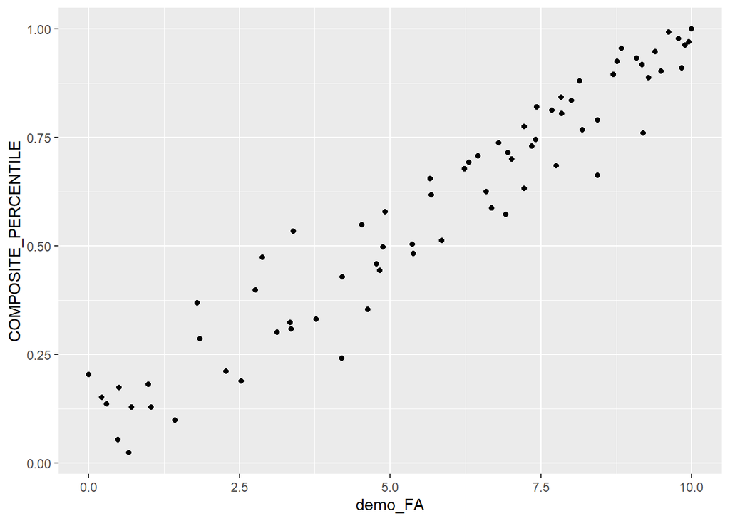

```r
base=ggplot(data=rseIndex,
            aes(x=demo_FA,y=COMPOSITE_PERCENTILE))
base+geom_point()
```

**Evaluation measures of our index for equity**

```r
evalCFA1=parameterEstimates(fit, standardized =TRUE)

evalCFA1[evalCFA1$op=="=~",c('rhs','std.all','pvalue')]
```

```
##                           rhs std.all pvalue
## 1 RACE_ELL_ORIGINS_PERCENTILE   0.788      0
## 2    SOCIOECONOMIC_PERCENTILE   1.003      0
## 3           HEALTH_PERCENTILE   0.877      0
```

```r
evalCFA2=as.list(fitMeasures(fit))
```

Chi-Squared

```r
evalCFA2[c("chisq", "df", "pvalue")]
```

```
## $chisq
## [1] 1.278977e-13
##
## $df
## [1] 0
##
## $pvalue
## [1] NA
```

Tucker-Lewis

```r
evalCFA2$tli # > 0.90
```

```
## [1] 1
```

RMSEA

```r
evalCFA2[c( 'rmsea.ci.lower','rmsea','rmsea.ci.upper')]
```

```
## $rmsea.ci.lower
## [1] 0
##
## $rmsea
## [1] 0
##
## $rmsea.ci.upper
## [1] 0
```

**SEM Model**

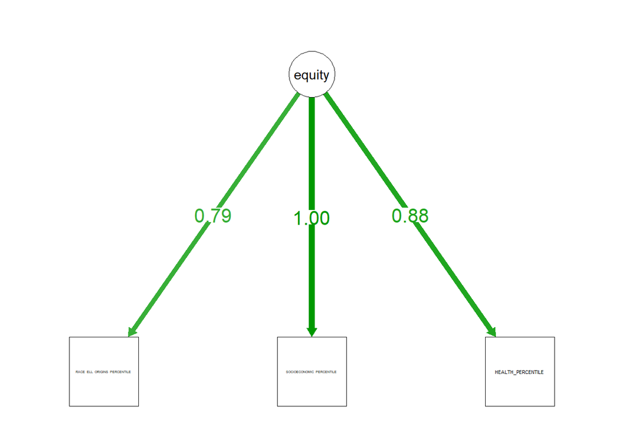

```r
library(semPlot)
semPaths(fit, what='std', nCharNodes=0, sizeMan=12,
         edge.label.cex=1.5, fade=T,residuals = F)
```

# Basic Modeling in R

## Prepare Data

Read in data for COVID cases by census tract from King County:

```
##   ï..Location_Name Population People_Tested People_Tested_Rate All_Test_Results
## 1       5.3033e+10   8156.852          5669           69499.85            15406
## 2       5.3033e+10   8511.072          6015           70672.65            15995
## 3       5.3033e+10   2861.162          2569           89788.69             8008
## 4       5.3033e+10   6613.086          4724           71434.12            12535
## 5       5.3033e+10   5375.182          3907           72685.91            11398
## 6       5.3033e+10   3366.652          2615           77673.61             7337
##   All_Test_Results_Rate Positives Positive_Rate Confirmed_Cases
## 1              188871.9      1047      12835.83            1000
## 2              187931.7       965      11338.17             927
## 3              279886.3       395      13805.58             368
## 4              189548.4       855      12928.91             820
## 5              212048.6       605      11255.43             578
## 6              217931.6       326       9683.21             314
##   Confirmed_Case_Rate Probable_Cases Probable_Case_Rate Hospitalizations
## 1            12259.63             47             576.20               37
## 2            10891.69             38             446.48               38
## 3            12861.91             27             943.67               11
## 4            12399.66             35             529.25               36
## 5            10753.12             27             502.31               22
## 6             9326.77             12             356.44                8
##   Hospitalization_Rate Deaths Death_Rate
## 1               453.61      5      61.30
## 2               446.48      5      58.75
## 3               384.46      4     139.80
## 4               544.38      7     105.85
## 5               409.29      9     167.44
## 6               237.62      2      59.41
```

Check column names for `covidData`

```r
covidData %>%
  colnames()
```

```
##  [1] "ï..Location_Name"      "Population"            "People_Tested"
##  [4] "People_Tested_Rate"    "All_Test_Results"      "All_Test_Results_Rate"
##  [7] "Positives"             "Positive_Rate"         "Confirmed_Cases"
## [10] "Confirmed_Case_Rate"   "Probable_Cases"        "Probable_Case_Rate"
## [13] "Hospitalizations"      "Hospitalization_Rate"  "Deaths"
## [16] "Death_Rate"
```

Merge `rseIndex` data with `covidData` by GEOID

```r
# merge datasets
demoCovid=merge(rseIndex,covidData,by.x = "GEOID10",by.y = "ï..Location_Name")

# omit NA values
demoCovid = na.omit(demoCovid)
```

Verifying data structure:

```r
str(demoCovid,width = 70,strict.width='cut')
```

```
## 'data.frame':    72 obs. of  61 variables:
##  $ GEOID10                       : num  5.3e+10 5.3e+10 5.3e+10 5.3e..
##  $ ï..OBJECTID                   : int  125 54 104 79 23 124 56 123 ..
##  $ Zip.Code                      : int  98125 98125 98125 98125 9812..
##  $ NAME10                        : num  1 2 3 6 7 8 9 10 11 19 ...
##  $ NAMELSAD10                    : chr  "Census Tract 1" "Census Tr"..
##  $ COMPOSITE_PERCENTILE          : num  0.805 0.677 0.685 0.73 0.745..
##  $ COMPOSITE_QUINTILE            : chr  "Highest priority/Most disa"..
##  $ RACE_ELL_ORIGINS_PERCENTILE   : num  0.79 0.745 0.391 0.685 0.76 ..
##  $ RACE_ELL_ORIGINS_QUINTILE     : chr  "Second highest" "Second hi"..
##  $ SOCIOECONOMIC_PERCENTILE      : num  0.79 0.632 0.775 0.737 0.745..
##  $ SOCIOECONOMIC_QUINTILE        : chr  "Second highest" "Second hi"..
##  $ HEALTH_PERCENTILE             : num  0.85 0.625 0.828 0.655 0.67 ..
##  $ HEALTH_QUINTILE               : chr  "Highest priority/Most disa"..
##  $ ACRES_TOTAL                   : num  457 812 299 948 320 ...
```

[output cut: 47 more lines]

## Continuous outcome

### Explanatory Approach

1. State hypotheses:

```r
# hypothesis 1: The disadvantage score increases as Confirmed Covid Case Rates increase:
hypo1=formula(COMPOSITE_PERCENTILE ~ Confirmed_Case_Rate)

# hypothesis 2: The disadvantage score increases as Confirmed Covid Case Rates, Hospitalization Rates, and Death Rates increase:

hypo2=formula(COMPOSITE_PERCENTILE~ Confirmed_Case_Rate + Hospitalization_Rate + Death_Rate)
```

2. Compute regression models:

```r
# results
gauss1=glm(hypo1,
           data = demoCovid,
           family = 'gaussian')

gauss2=glm(hypo2,
           data = demoCovid,
           family = 'gaussian')
```

3. See results:

First Hypothesis: For every one unit increase in the `Confirmed_Case_Rate`, there is a 0.00006367 unit increase in the `COMPOSITE_PERCENTILE` (disadvantage scale), which is statistically significant.

```r
summary(gauss1)
```

```
##
## Call:
## glm(formula = hypo1, family = "gaussian", data = demoCovid)
##
## Deviance Residuals:
##      Min        1Q    Median        3Q       Max
## -0.46173  -0.14584   0.02529   0.12857   0.58403
##
## Coefficients:
##                       Estimate Std. Error t value Pr(>|t|)
## (Intercept)         -1.829e-01  9.642e-02  -1.897    0.062 .
## Confirmed_Case_Rate  6.367e-05  7.755e-06   8.210  7.5e-12 ***
## ---
## Signif. codes:  0 '***' 0.001 '**' 0.01 '*' 0.05 '.' 0.1 ' ' 1
##
## (Dispersion parameter for gaussian family taken to be 0.0409522)
##
##     Null deviance: 5.6269  on 71  degrees of freedom
## Residual deviance: 2.8667  on 70  degrees of freedom
## AIC: -21.766
##
## Number of Fisher Scoring iterations: 2
```

Second Hypothesis: Holding `Hospitalization_Rate` and `Death_Rate` constant, for every one unit increase in the `Confirmed_Case_Rate`, there is a 0.00004536 increase in the `COMPOSITIE_PERCENTILE` (disadvantage score), which is statistically significant. This rate is the only statistically significant variable. However, the `Hospitalization_Rate` is close to being statistically significant at the 10% confidence interval.

```r
summary(gauss2)
```

```
##
## Call:
## glm(formula = hypo2, family = "gaussian", data = demoCovid)
##
## Deviance Residuals:
##      Min        1Q    Median        3Q       Max
## -0.43207  -0.13842   0.01857   0.13250   0.48787
##
## Coefficients:
##                        Estimate Std. Error t value Pr(>|t|)
## (Intercept)          -5.097e-02  1.125e-01  -0.453 0.651789
## Confirmed_Case_Rate   4.536e-05  1.103e-05   4.113 0.000108 ***
## Hospitalization_Rate  1.800e-04  1.106e-04   1.628 0.108239
## Death_Rate            2.262e-04  2.881e-04   0.785 0.435126
## ---
## Signif. codes:  0 '***' 0.001 '**' 0.01 '*' 0.05 '.' 0.1 ' ' 1
##
## (Dispersion parameter for gaussian family taken to be 0.03858697)
##
##     Null deviance: 5.6269  on 71  degrees of freedom
## Residual deviance: 2.6239  on 68  degrees of freedom
## AIC: -24.137
##
## Number of Fisher Scoring iterations: 2
```

4. Search for *better* model:

```r
anova(gauss1,gauss2,test="Chisq")
```

```
## Analysis of Deviance Table
##
## Model 1: COMPOSITE_PERCENTILE ~ Confirmed_Case_Rate
## Model 2: COMPOSITE_PERCENTILE ~ Confirmed_Case_Rate + Hospitalization_Rate +
##     Death_Rate
##   Resid. Df Resid. Dev Df Deviance Pr(>Chi)
## 1        70     2.8666
## 2        68     2.6239  2  0.24274  0.04305 *
## ---
## Signif. codes:  0 '***' 0.001 '**' 0.01 '*' 0.05 '.' 0.1 ' ' 1
```

RSquared for second hypothesis

```r
library(rsq)
rsq(gauss2,adj=T)
```

```
## [1] 0.513109
```

5. Verify the situation of chosen model:

5.1. The linear relationships does not hold that well:

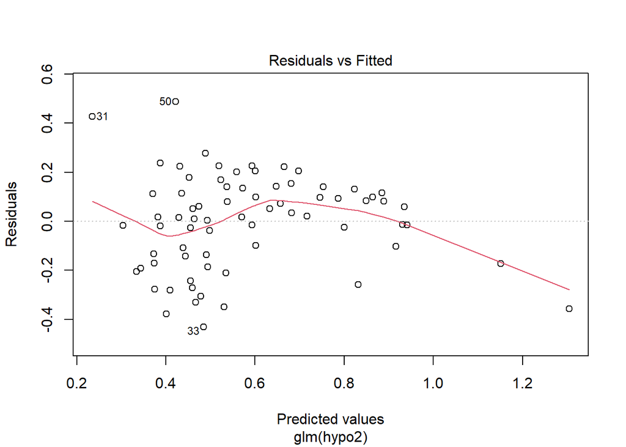

```r
plot(gauss2,1)
```

5.2. Normality of residuals is assumed:

Visual exploration:

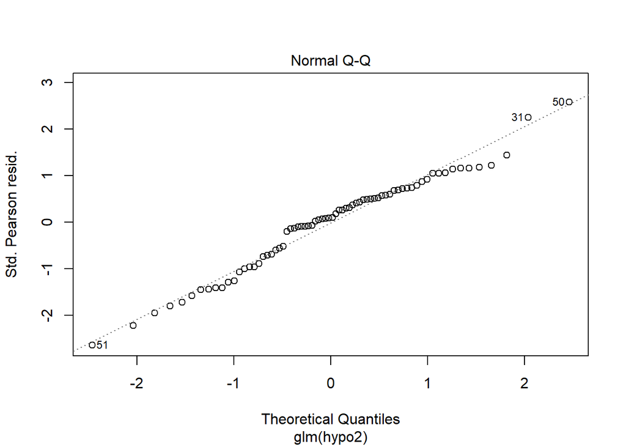

```r
plot(gauss2,2)
```

Mathematical exploration: The data is normal because the p-value > 0.05

```r
shapiro.test(gauss2$residuals)
```

```
##
##  Shapiro-Wilk normality test
##
## data:  gauss2$residuals
## W = 0.97428, p-value = 0.1468
```

5.3. Homoscedasticity

Visual exploration:

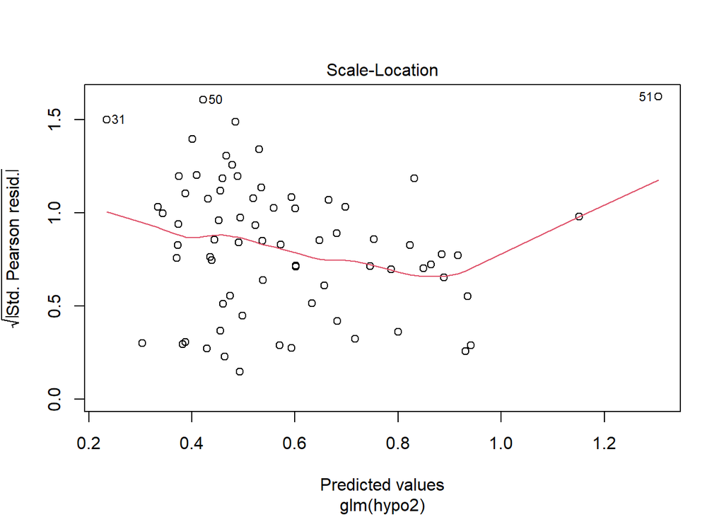

```r
plot(gauss2, 3)
```

Mathematical exploration: p-value is <0.05 so I cannot assume homoscedasticity

```r
library(lmtest)
bptest(gauss2)
```

```
##
##  studentized Breusch-Pagan test
##
## data:  gauss2
## BP = 12.771, df = 3, p-value = 0.005159
```

5.4. There is no collinearity because the VIFs are lower than 5.

```r
library(car)
vif(gauss2) # lower than 5 is desirable
```

```
##  Confirmed_Case_Rate Hospitalization_Rate           Death_Rate
##             2.146527             2.917445             1.638092
```

5.5. Analyzing the effect of atypical values

Visual exploration:

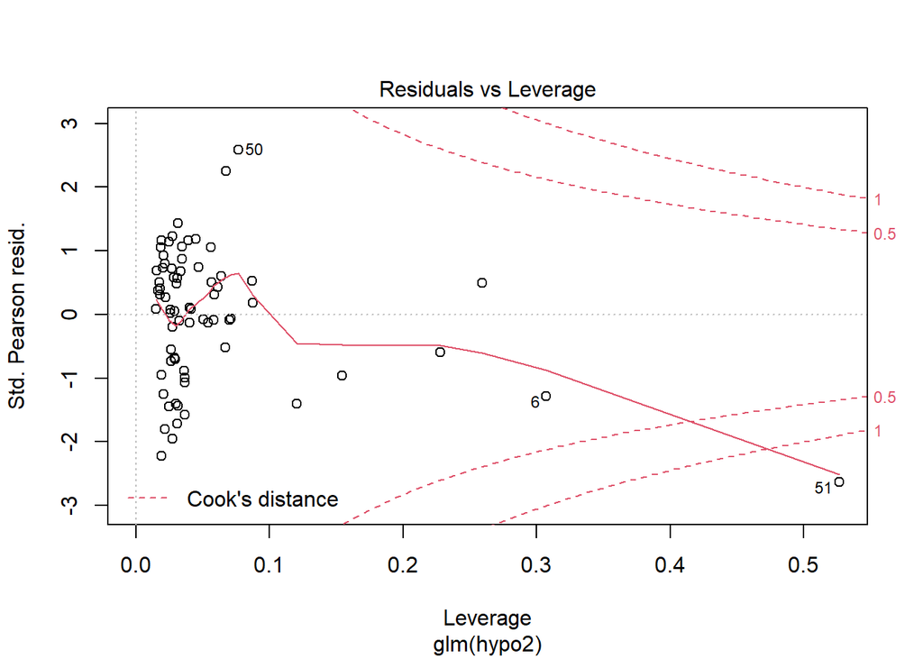

```r
plot(gauss2,5)
```

Querying:

```r
gaussInf=as.data.frame(influence.measures(gauss2)$is.inf)
gaussInf[gaussInf$cook.d,]
```

```
##    dfb.1_ dfb.C_C_ dfb.Hs_R dfb.Dt_R dffit cov.r cook.d  hat
## 51  FALSE     TRUE     TRUE    FALSE  TRUE  TRUE   TRUE TRUE
```

6. Summary plot

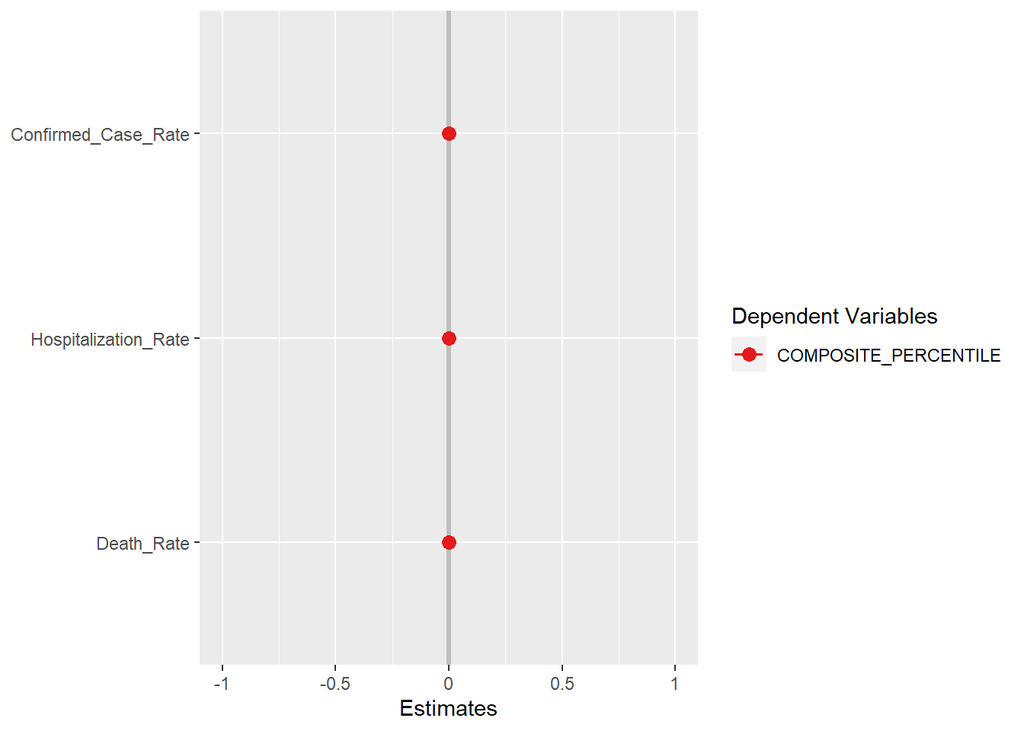

```r
library(sjPlot)
plot_models(gauss2,vline.color = "grey")
```